# LMM

04/13/2015

```r
library(lme4)
library(arm)
```

```r
library(heritability)
library(ggplot2)
library(plyr)
```

Read and subset the data. Keep the last 5 Transfers, 5 Days per Transfer and only the 0 ppt Treatment. Make sure the factors are factors.

```r
CSALT <- read.csv("./CSALT.csv", header= TRUE)

last5zero <- droplevels(CSALT[which(CSALT$Treatment == 0 &
                                      CSALT$Transfer > 13 &
                                      CSALT$trDay > 1 &
                                      CSALT$trDay < 7), ])

last5zero <- mutate(last5zero,
                Treatment=factor(Treatment),
                Replicate=factor(Replicate),
                seqRep=factor(seqRep),
                trDay=trDay-1, # so that the first measurement is at day 1
                Rep=factor(Rep),
                Transfer=factor(Transfer))
head(last5zero)
```

```
##      Number Experiment       Date Day Hour Transfer Strain Media
## 3501      1   salinity 2015-03-18  56   24       14    331   ASW
## 3502      2   salinity 2015-03-18  56   24       14    332   ASW
## 3503      3   salinity 2015-03-18  56   24       14    333   ASW
## 3504      4   salinity 2015-03-18  56   24       14   1263   ASW
## 3521     21   salinity 2015-03-18  56   24       14    331   ASW
## 3522     22   salinity 2015-03-18  56   24       14    332   ASW
##      Temperature Treatment Replicate    RF Rfctrl Rep seqRep  lnRF trDay
## 3501          15         0         1 510.2  19.37   1      N 6.196     1
## 3502          15         0         1 590.1  19.37   1      N 6.347     1
## 3503          15         0         1 402.2  19.37   1      N 5.948     1
## 3504          15         0         1 383.5  19.37   1      N 5.898     1
## 3521          15         0         2 442.9  19.37   2      N 6.049     1
## 3522          15         0         2 412.3  19.37   2      N 5.974     1
```

Make a function to fit and plot model

```r
fitPlotRep <- function(Formula, Reform) {
  mod <- lmer(formula = Formula, data=last5zero)

  newDAT <- last5zero
  newDAT$pred <- predict(mod, newDAT, re.form=Reform)

  pl <- ggplot(aes(y=lnRF, x=trDay, group=Rep, colour=Rep), data=newDAT) +
        geom_line(aes(y=pred, group=Rep, colour=Rep), data=newDAT) +
        geom_point() +
        facet_grid(. ~ Strain) # superimposed doesn't work for some reason?
  return(list(mod, pl))
}

fitPlotSeqRep <- function(Formula, Reform) {
  mod <- lmer(formula = Formula, data=last5zero)

  newDAT <- last5zero
  newDAT$pred <- predict(mod, newDAT, re.form=Reform)

  pl <- ggplot(aes(y=lnRF, x=trDay, group=seqRep, colour=seqRep), data=newDAT) +
        geom_line(aes(y=pred, group=seqRep, colour=seqRep), data=newDAT) +
        geom_point() +
        facet_grid(. ~ Strain) # superimposed doesn't work for some reason?
  return(list(mod, pl))
}
```

Nesting vs. interacion, as far as I understand it.

- The notation `factorA:factorB` is a ‘simple’ interaction. It returns only the effects of the combinations of factors A and B
- The notation `factorA/factorB` is nesting; B is nested in A. It returns the effects of the combinations of factors A and B as well as the ‘main’ effects of the groups of A.

Fit a linear *mixed* model with different slopes and intercepts using `lmer`. This model is *unaware* of Replicate or Transfer but aware of Strain.

```r
Formula <- formula(lnRF ~ trDay + (1 + trDay | Strain))
Reform <- formula(~(1 + trDay | Strain))
m1 <- fitPlotRep(Formula, Reform)
```

The `fitPlot` function returns a list of the fitted model and a plot. The plot shows that a separate regression was calculated for each Strain. When we look at the fixed effects (`fixef`) in the model we see one intercept and one slope. When we look at the random effects (`ranef`) we see the effect that each Strain has on the coefficients of the model. The way I understand this is that each group in the random effect modifies the coefficients of the fixed effect. So for Strain 331 the slope would be `0.66 + 0.034`.

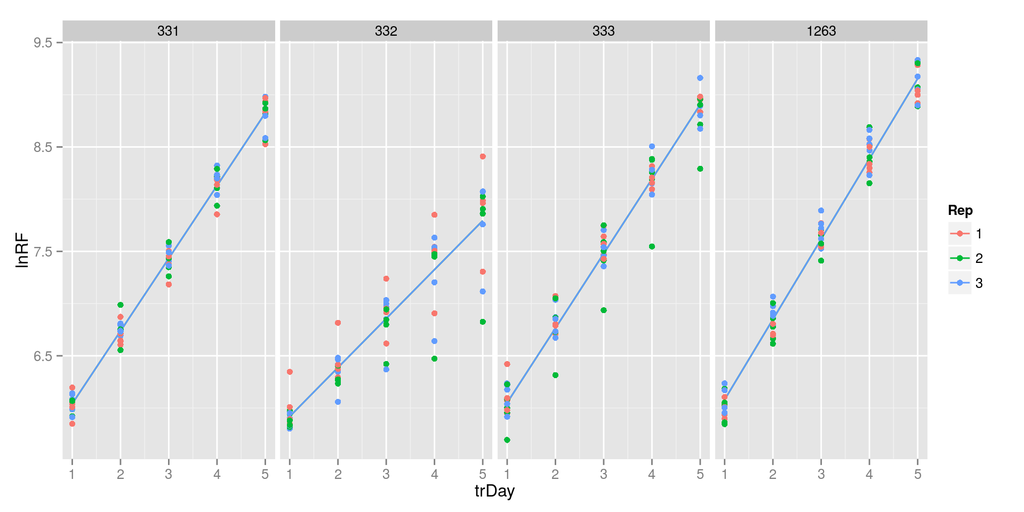

```r
m1[[2]]
```

```r
fixef(m1[[1]])
```

```
## (Intercept)       trDay
##      5.3606      0.6619
```

```r
ranef(m1[[1]])
```

```
## $Strain
##      (Intercept)    trDay
## 331     -0.01577  0.03417
## 332      0.08906 -0.19298
## 333     -0.02406  0.05214
## 1263    -0.04922  0.10667
```

Now lets try to nest Replicate within Strain.

```r
Formula <- formula(lnRF ~ trDay + (1 + trDay | Strain/Rep))
Reform <- formula(~(1 + trDay | Strain/Rep))
m2 <- fitPlotRep(Formula, Reform)
```

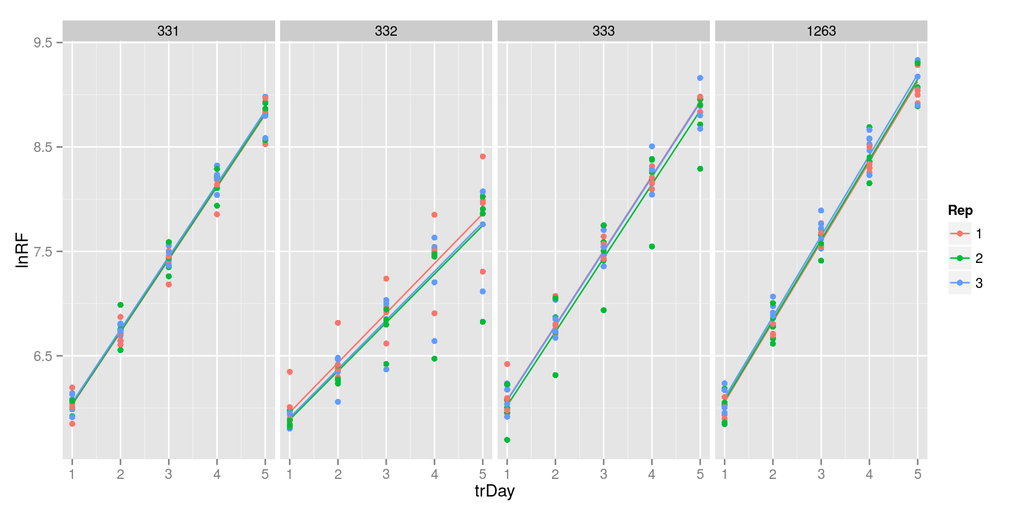

```r
m2[[2]]
```

```r
fixef(m2[[1]])
```

```
## (Intercept)       trDay
##      5.3606      0.6619
```

```r
ranef(m2[[1]])
```

```
## $`Rep:Strain`
##        (Intercept)      trDay
## 1:331    -0.008770 -0.0016301
## 1:332     0.031291  0.0058163
## 1:333     0.024450  0.0045447
## 1:1263   -0.020114 -0.0037388
## 2:331    -0.003188 -0.0005926
## 2:332    -0.026787 -0.0049791
## 2:333    -0.021211 -0.0039426
## 2:1263   -0.008101 -0.0015058
## 3:331     0.009753  0.0018128
## 3:332    -0.012124 -0.0022536
## 3:333     0.018715  0.0034787
## 3:1263    0.016086  0.0029900
##
## $Strain
##      (Intercept)    trDay
## 331     -0.01618  0.03462
## 332      0.08977 -0.19204
## 333     -0.02264  0.04842
## 1263    -0.05095  0.10899
```

What about separate slopes for each replicate?

```r
Formula <- formula(lnRF ~ trDay + (1 + trDay | Strain) + (1 + trDay | Rep))
Reform <- formula(~(1 + trDay | Strain) + (1 + trDay | Rep))
m3 <- fitPlotRep(Formula, Reform)
```

This is not the model I was thinking it was. Fixed effect is the same as before. Random effects are ones for each group of Strain and Replicate regardless of Strain. The plot is different, appears that regression lines are only plotted for reps 2 and 3.

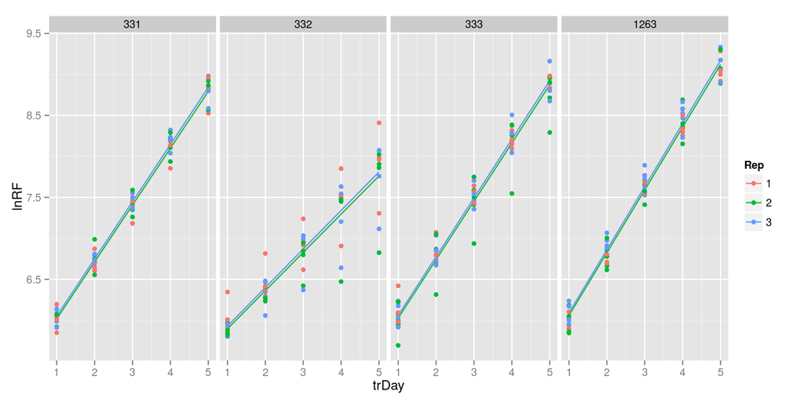

```r
m3[[2]]
```

```r
fixef(m3[[1]])
```

```
## (Intercept)       trDay
##      5.3606      0.6619
```

```r
ranef(m3[[1]])
```

```
## $Strain
##      (Intercept)    trDay
## 331     -0.01577  0.03417
## 332      0.08906 -0.19299
## 333     -0.02406  0.05214
## 1263    -0.04923  0.10667
##
## $Rep
##   (Intercept)     trDay
## 1    0.008971  0.001142
## 2   -0.020106 -0.002560
## 3    0.011135  0.001418
```

Another try. What about separate slopes for each replicate? This time nest Strain within Replicate?

```r
Formula <- formula(lnRF ~ trDay + (1 + trDay | Rep/Strain))
Reform <- formula(~(1 + trDay | Rep/Strain))
m4 <- fitPlotRep(Formula, Reform)
```

This model produced three regression lines with apparently different slopes but same intercepts. Random effects point to the difference in nesting. The notation `Rep/Strain` means Strain is nested within Replicate; and the `ranef()` output shows coefficients for the interactions `Strain:Rep` plus the effects of each Replicate (very small).

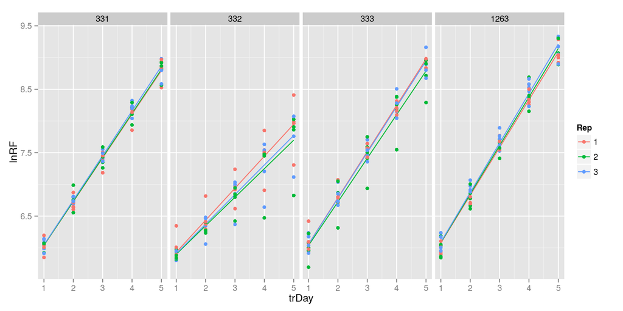

```r
m4[[2]]
```

```r
fixef(m4[[1]])
```

```
## (Intercept)       trDay
##      5.3606      0.6619
```

```r
ranef(m4[[1]])
```

```
## $`Strain:Rep`
##        (Intercept)    trDay
## 331:1     -0.01133  0.02713
## 331:2     -0.01292  0.03093
## 331:3     -0.01757  0.04208
## 332:1      0.06576 -0.15743
## 332:2      0.08865 -0.21225
## 332:3      0.08189 -0.19605
## 333:1     -0.02794  0.06689
## 333:2     -0.01069  0.02560
## 333:3     -0.02530  0.06057
## 1263:1    -0.03787  0.09066
## 1263:2    -0.04307  0.10312
## 1263:3    -0.04960  0.11875
##
## $Rep
##   (Intercept)      trDay
## 1           0  1.734e-14
## 2           0 -1.038e-13
## 3           0  8.642e-14
```

This is not generally what we want, the Replicates should be ‘components’ of Strain, not the other way around. I think at least.